# NUC Dual Bayesian Inference Models

Bianca Pfahl

19.02.2022

#### 1. Data

Reading in data from the main experiment (experiment 1-3) and the norming study

Choice Data from Main Experiment:

```r
all_choice_data
```

```
## # A tibble: 8 x 4
##   condition_nr condition                red_toy sample_size
##          <dbl> <chr>                      <dbl>       <dbl>
## 1            1 Rewards & Costs                4          25
## 2            2 Different Costs                4          25
## 3            3 Different Rewards             17          25
## 4            4 Medium Cost Conflict          14          25
## 5            5 High Cost Conflict            10          25
## 6            6 Extra-High Cost Conflict       6          25
## 7            7 Exp2: Teach                    7          25
## 8            8 Exp3: Exploration              5          25
```

Norming Data:

```r
d_norm_compact
```

```
## # A tibble: 1 x 3
##   Preference Lights SampleSize
##   <chr>       <int>      <int>
## 1 lights         20         25
```

Combining all data from main experiment & norming study into a list to parse to Stan

cost matrix: dimension 1 stands for: activation [1] or discovery [2] cost, dimension 2 stands for the 4 toy difficulty levels [1-4]

reward_vec_red/yellow and cost_vec_red/yellow indicate the indices to access the correct rewards & costs per condition

```r
# transforming cost values from (0,100) interval to (0,1) inverval
costs = matrix(c(1,1,1,4,2,29,2,79), nrow=2, ncol=4)
costs = costs / 100


choice_data_list = list(
  k = all_choice_data$red_toy, n = all_choice_data$sample_size, n_conditions = 8, rewards_vec_red = c(1,1,2,2,2,2,2,1),
  rewards_vec_yellow = c(2,1,1,1,1,1,1,1), cost_vec_red = c(1,1,1,1,1,1,1,1), cost_vec_yellow  = c(3,3,1,2,3,4,3,3),costs = costs
)

d_norm_list <- list(k_norm = d_norm_compact$Lights, n_norm = d_norm_compact$SampleSize)

# Combining data from norming study and rest

data_and_norm <- append(choice_data_list, d_norm_list)

data_and_norm
```

```
## $k
## [1]  4  4 17 14 10  6  7  5
##
## $n
## [1] 25 25 25 25 25 25 25 25
##
## $n_conditions
## [1] 8
##
## $rewards_vec_red
## [1] 1 1 2 2 2 2 2 1
##
## $rewards_vec_yellow
## [1] 2 1 1 1 1 1 1 1
##
## $cost_vec_red
## [1] 1 1 1 1 1 1 1 1
##
## $cost_vec_yellow
## [1] 3 3 1 2 3 4 3 3
##
## $costs
##      [,1] [,2] [,3] [,4]
## [1,] 0.01 0.01 0.02 0.02
## [2,] 0.01 0.04 0.29 0.79
##
## $k_norm
## [1] 20
##
## $n_norm
## [1] 25
```

```r
# creating a slightly altered version for the cost models
```

The following code chunk generates the data for Table 1 from the thesis:

```r
pretty_costs <- tibble(
  Costs = c("low", "medium", "high", "extra high"),
  Activation_Cost = c(0.01,0.01,0.02,0.02),
  Discovery_Cost = c(0.01,0.04,0.29,0.79)
)

pretty_costs
```

```
## # A tibble: 4 x 3
##   Costs      Activation_Cost Discovery_Cost
##   <chr>                <dbl>          <dbl>
## 1 low                   0.01           0.01
## 2 medium                0.01           0.04
## 3 high                  0.02           0.29
## 4 extra high            0.02           0.79
```

```r
print(xtable(pretty_costs, type = "latex"), file = "costs_table.tex")
```

#### 2. Models

#### 2.1 Main Model: Dual Bayesian Inference Model

```stan
// Dual Bayesian Inference Model (Main Model)
// The model performs dual Bayesian inference over two distinct data sets: the main experiment data and norming study
// data from Bridgers et al. (2020)

data {
  int<lower=1> n_conditions;
  int<lower=0> k[n_conditions];
  int<lower=1> n[n_conditions];
  int<lower=1> n_norm;
  int<lower=0> k_norm;

  // REWARD indices
  int rewards_vec_red[n_conditions];
  int rewards_vec_yellow[n_conditions];

  // COST indices
  int cost_vec_red[n_conditions];
  int cost_vec_yellow[n_conditions];

  // COST VECTOR
  real costs[2,4];
}
parameters {

  //REWARD VECTOR: reward[1] corresponds to the music mechanism, reward[2] corresponds to the light mechanism
  real<lower=0, upper=1> rewards[2];

}

model {
  real utility_toy_red;
  real utility_toy_yellow;
  real prob_choice_red;
  real prob_lights;

  // HYPERPARAMETERS
  real alpha = 5;
  real explo_para = 0.5;

  // PRIORS
  rewards[1]  ~ beta(1,1);
  rewards[2] ~ beta(1,1);

 // MAIN LOOP: going through all 6 conditions of the experiment

  for (i in 1:n_conditions) {

    // UTILITIES
    // computing utility values for red toy and yellow toy respectively, according to condition
    utility_toy_red = rewards[rewards_vec_red[i]] - costs[1][cost_vec_red[i]] + explo_para * rewards[rewards_vec_yellow[i]] - costs[2][cost_vec_yellow[i]];
    utility_toy_yellow = rewards[rewards_vec_yellow[i]] - costs[1][cost_vec_yellow[i]] + explo_para * rewards[rewards_vec_red[i]] - costs[2][cost_vec_red[i]];

    // PROBABILITY FOR RED TOY
    // computing the probability for a child to choose the red toy using softmax choice rule
    prob_choice_red = exp(alpha * utility_toy_red) / (exp(alpha * utility_toy_red) + exp(alpha * utility_toy_yellow));

    // POSTERIOR
    // Observed amount of decisions for red toy
    k[i] ~ binomial(n[i], prob_choice_red);
  }

  // NORMING STUDY

  //PROBABILITY FOR LIGHT TOY
  // computing the probability for a child to choose the light toy using softmax choice rule
  prob_lights = exp(alpha * rewards[2]) / (exp(alpha * rewards[2]) + exp(alpha*rewards[1]));

  // NORMING STUDY POSTERIOR
  // Observed amount of decisions for light toy
  k_norm ~ binomial(n_norm, prob_lights);
}
```

The following code chunk creates the data for Table 2 from the thesis:

```r
Dual_Bayesian_Inference_Model_tibble <- summary(Dual_Bayesian_Inference_Model)$summary

Dual_Bayesian_Inference_Model_tibble
```

```
##                    mean     se_mean        sd         2.5%          25%
## rewards[1]    0.3519660 0.003323107 0.2085143    0.0199391    0.1691950
## rewards[2]    0.6478134 0.003316924 0.2090956    0.2857084    0.4708817
## lp__       -136.6893587 0.019134232 1.1732540 -139.7481324 -137.2115770
##                     50%          75%        97.5%    n_eff     Rhat
## rewards[1]    0.3470174    0.5287344    0.7152871 3937.161 1.000406
## rewards[2]    0.6498212    0.8296556    0.9840868 3973.916 1.000247
## lp__       -136.3500632 -135.8199098 -135.4737928 3759.777 1.000286
```

```r
print(xtable(Dual_Bayesian_Inference_Model_tibble, type = "latex"), file = "Dual_Bayesian_Inference_Model_Output.tex")
```

Visualising the Results: Dual Bayesian Inference Model

The following code chunk creates Figure 6 (Left) from the thesis:

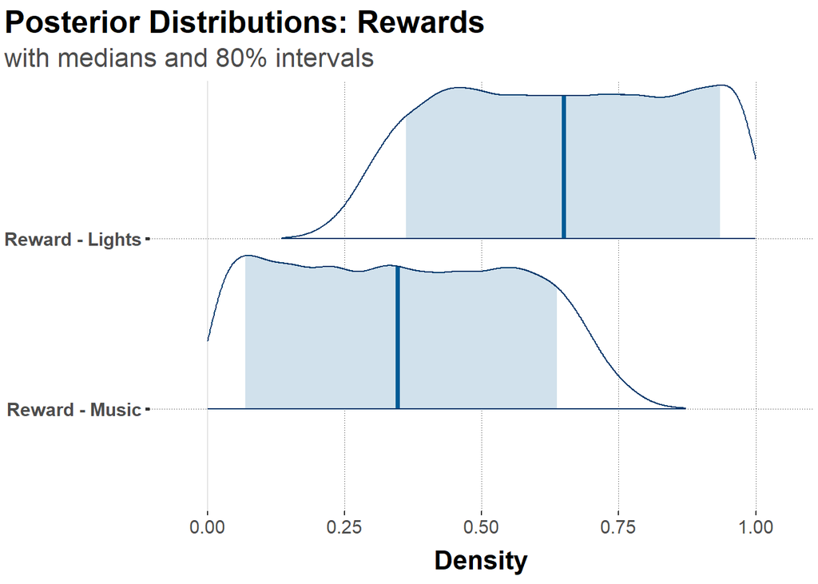

```r
# extract samples from the stanfit object
Dual_Bayesian_Inference_Model_samples <- tidybayes::tidy_draws(Dual_Bayesian_Inference_Model)

Dual_Bayesian_Inference_Model_samples_matrix <- as.matrix(Dual_Bayesian_Inference_Model_samples)

mcmc_areas(Dual_Bayesian_Inference_Model_samples_matrix,
           regex_pars = "rewards\\[[1-2]\\]", prob = 0.8, area_method = "equal height") +
  scale_y_discrete(
      labels = c("rewards[1]" = "Reward - Music",
             "rewards[2]" = "Reward - Lights"
             )) +
       labs(x="Density",
   title = "Posterior Distributions: Rewards",
   subtitle = "with medians and 80% intervals") +
  theme(plot.title.position = "plot",
        plot.caption.position =  "plot") +
  legend_move("none")
```

```r
dev.copy(png,filename="Dual_Bayesian_Inference_Model_posteriors.png")
```

```r
dev.off ()
```

The following code chunk creates Figure 6 (Right) from the thesis:

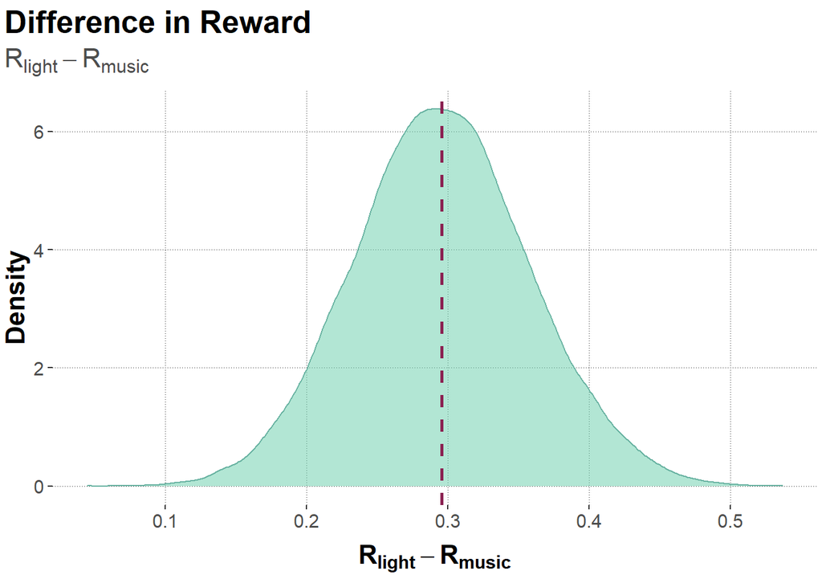

```r
Dual_Bayesian_Inference_Model_samples <- Dual_Bayesian_Inference_Model_samples %>%
                  mutate(difference = `rewards[2]` - `rewards[1]`,
                         mean_difference = mean(difference))

# accessing the mean difference between the two rewards
mean_difference = Dual_Bayesian_Inference_Model_samples$mean_difference[1]

color_scheme_set("teal")

Dual_Bayesian_Inference_reward_difference_plot <- ggplot(Dual_Bayesian_Inference_Model_samples, aes(x=`difference`)) + geom_density(color="#69b3a2",fill="mediumaquamarine", alpha=0.5) + geom_vline(xintercept=mean_difference, color="violetred4", size=1,linetype="dashed") +
  labs(x=expression(bold(R[light] - R[music])), y="Density",
   title = "Difference in Reward",
   subtitle = expression(R[light] - R[music])) +
  theme(plot.title.position = "plot",
        plot.caption.position =  "plot")

Dual_Bayesian_Inference_reward_difference_plot
```

```r
dev.copy(png,filename="Dual_Bayesian_Inference_Reward_Difference.png")
```

```r
dev.off ()
```

Hypothesis Tests: Dual Bayesian Inference Model

The following code chunk creates the data for Table 3 from the thesis:

```r
# employing a one-sided hypothesis from the brms package to check if the posterior for reward music and reward light are credibly different

hypothesis_test_Dual_Bayesian_Inference_Model <- hypothesis(Dual_Bayesian_Inference_Model_samples, 'rewards[2] > rewards[1]')

hypothesis_test_Dual_Bayesian_Inference_Model
```

```
## Hypothesis Tests for class :
##                 Hypothesis Estimate Est.Error CI.Lower CI.Upper Evid.Ratio
## 1 (rewards[2])-(rew... > 0      0.3      0.06     0.19      0.4        Inf
##   Post.Prob Star
## 1         1    *
## ---
## 'CI': 90%-CI for one-sided and 95%-CI for two-sided hypotheses.
## '*': For one-sided hypotheses, the posterior probability exceeds 95%;
## for two-sided hypotheses, the value tested against lies outside the 95%-CI.
## Posterior probabilities of point hypotheses assume equal prior probabilities.
```

```r
print(xtable(hypothesis_test_Dual_Bayesian_Inference_Model$hypothesis, type = "latex"), file = "hypothesis_table_2rewards.tex")
```

##### 2.2 Four Rewards Model

Stan Model:

```stan
// Four Rewards Model
// The model performs dual Bayesian inference over two distinct data sets: the main experiment data and norming study
// data from Bridgers et al. (2020) and estimates separat values per activation and discovery reward per toy.

data {
  int<lower=1> n_conditions;
  int<lower=0> k[n_conditions];
  int<lower=1> n[n_conditions];
  int<lower=1> n_norm;
  int<lower=0> k_norm;

  // REWARDS indices
  int rewards_vec_red[n_conditions];
  int rewards_vec_yellow[n_conditions];

  // COSTS indices
  int cost_vec_red[n_conditions];
  int cost_vec_yellow[n_conditions];

  // COST VECTOR
  real costs[2,4];
}
parameters {

 //REWARD VECTOR: reward[1] corresponds to the music mechanism, reward[2] corresponds to the light mechanism
  real<lower=0, upper=1> rewards[2,2];

}

model {
  real utility_toy_red;
  real utility_toy_yellow;
  real prob_choice_red;
  real prob_lights;

  // HYPERPARAMETERS
  real alpha = 5;
  real explo_para = 0.5;

  // REWARDS

  // activation reward for music effect toy
  rewards[1][1]  ~ beta(1,1);

  // activation reward for light effect toy
  rewards[1][2] ~ beta(1,1);

  // discovery reward for music effect toy
  rewards[2][1] ~ beta(1,1);

  // discovery reward for light effect toy
  rewards[2][2] ~ beta(1,1);

 // MAIN LOOP: going through all 6 conditions of the experiment

  for (i in 1:n_conditions) {

    // UTILITIES
    // computing utility values for red toy and yellow toy respectively according to condition, using seperate
    // variables for discovery and action reward depending on context the toy is presented in
    utility_toy_red = rewards[1][rewards_vec_red[i]] - costs[1][cost_vec_red[i]] + explo_para * rewards[2][rewards_vec_yellow[i]] -   costs[2][cost_vec_yellow[i]];
    utility_toy_yellow = rewards[1][rewards_vec_yellow[i]] - costs[1][cost_vec_yellow[i]] + explo_para * rewards[2][rewards_vec_red[i]] - costs[2][cost_vec_red[i]];

    // PROBABILITIES
   // computing the probability for a child to choose the red toy using softmax choice rule
    prob_choice_red = exp(alpha * utility_toy_red) / (exp(alpha * utility_toy_red) + exp(alpha * utility_toy_yellow));

    // POSTERIOR
    // Observed amount of decisions for red toy
    k[i] ~ binomial(n[i], prob_choice_red);
  }

  // NORMING STUDY

  //PROBABILITY FOR LIGHT TOY
  // computing the probability for a child to choose the light toy using softmax choice rule
  prob_lights = exp(alpha * rewards[2][2]) / (exp(alpha * rewards[2][2]) + exp(alpha*rewards[2][1]));

  // NORMING STUDY POSTERIOR
  // Observed amount of decisions for light toy
  k_norm ~ binomial(n_norm, prob_lights);
}
```

The following code chunk creates the data for Table 4 from the thesis:

```r
Four_Rewards_Model
```

```
## Inference for Stan model: Four_Rewards_Model.
## 4 chains, each with iter=10000; warmup=5000; thin=1;
## post-warmup draws per chain=5000, total post-warmup draws=20000.
##
##                 mean se_mean   sd    2.5%     25%     50%     75%   97.5% n_eff
## rewards[1,1]    0.35    0.00 0.21    0.02    0.17    0.35    0.53    0.72  7707
## rewards[1,2]    0.64    0.00 0.21    0.28    0.47    0.64    0.83    0.98  7696
## rewards[2,1]    0.37    0.00 0.22    0.02    0.18    0.36    0.54    0.78  7475
## rewards[2,2]    0.64    0.00 0.22    0.23    0.46    0.65    0.83    0.99  7523
## lp__         -140.86    0.03 1.74 -145.22 -141.74 -140.49 -139.59 -138.63  4246
##              Rhat
## rewards[1,1]    1
## rewards[1,2]    1
## rewards[2,1]    1
## rewards[2,2]    1
## lp__            1
##
## Samples were drawn using NUTS(diag_e) at Sat Feb 19 21:37:03 2022.
## For each parameter, n_eff is a crude measure of effective sample size,
## and Rhat is the potential scale reduction factor on split chains (at
## convergence, Rhat=1).
```

```r
Four_Rewards_Model_tibble <- summary(Four_Rewards_Model)$summary
print(xtable(Four_Rewards_Model_tibble, type = "latex"), file = "four_rewards_summary.tex")
```

The following code chunk creates the data for Table 5 from the thesis:

```r
# is discovery reward > activation reward for music toy?
Four_Rewards_Model_hypothesis1 <- hypothesis(Four_Rewards_Model, "rewards[2,1] > rewards[1,1]")

# is discovery reward > activation reward for light toy?
Four_Rewards_Model_hypothesis2 <- hypothesis(Four_Rewards_Model, "rewards[2,2] > rewards[1,2]")

Four_Rewards_Model_Hypothesis_Tests <- bind_rows(Four_Rewards_Model_hypothesis1$hypothesis,Four_Rewards_Model_hypothesis2$hypothesis)

Four_Rewards_Model_Hypothesis_Tests
```

```
##                          Hypothesis    Estimate Est.Error   CI.Lower  CI.Upper
## 1 (rewards[2,1])-(rewards[1,1]) > 0  0.01440427 0.2994891 -0.4849560 0.5111093
## 2 (rewards[2,2])-(rewards[1,2]) > 0 -0.00451435 0.2993425 -0.5103124 0.4861514
##   Evid.Ratio Post.Prob Star
## 1   1.076412   0.51840
## 2   1.012275   0.50305
```

```r
print(xtable(Four_Rewards_Model_Hypothesis_Tests, type = "latex"), file = "Four_Rewards_Model_Hypothesis_Tests.tex")
```

The following code chunk creates Figure 8 (Left) from the thesis:

[figure not shown]

```r
# extract samples from the stanfit object
Four_Rewards_Model_samples <- tidybayes::tidy_draws(Four_Rewards_Model)

Four_Rewards_Model_samples_matrix <- as.matrix(Four_Rewards_Model_samples)

Four_Rewards_Model_Posteriors_plot <- mcmc_areas(Four_Rewards_Model_samples_matrix,
           regex_pars = "rewards\\[[1-2],[1-2]\\]", prob = 0.5, prob_outer = 0.95,  area_method = "equal heigh") +
  scale_y_discrete(
      labels = c("rewards[1,1]" = "Activation Reward - Music",
             "rewards[1,2]" = "Activation Reward - Lights",
             "rewards[2,1]" = "Discovery Reward - Music",
             "rewards[2,2]" = "Discovery Reward - Lights")) +
      labs(x="Density",
      title = "Posterior Distributions: Rewards",
      subtitle = "with medians and 80% intervals") +
      theme(plot.title.position = "plot",
        plot.caption.position =  "plot")
Four_Rewards_Model_Posteriors_plot
```

```r
dev.copy(png,filename="Four_Rewards_Model_Posteriors.png")
dev.off ()
```

The following code chunk creates Figure 8 (Right) from the thesis:

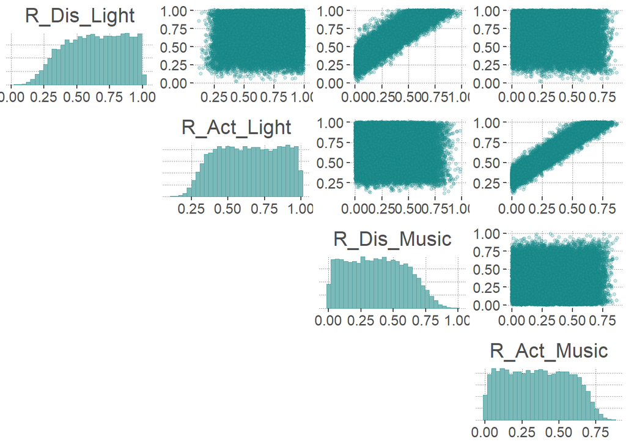

```r
Four_Rewards_Model_samples_matrix <- Four_Rewards_Model_samples %>%
    mutate(R_Act_Music = Four_Rewards_Model_samples$`rewards[1,1]`,
           R_Act_Light = Four_Rewards_Model_samples$`rewards[1,2]`,
           R_Dis_Music = Four_Rewards_Model_samples$`rewards[2,1]`,
           R_Dis_Light = Four_Rewards_Model_samples$`rewards[2,2]`)

Four_Rewards_Model_Scatter_Plots <- mcmc_pairs(Four_Rewards_Model_samples_matrix, pars = c("R_Dis_Light", "R_Act_Light", "R_Dis_Music" ,"R_Act_Music"),
                             off_diag_args = list(size = 1, alpha = 0.25))
Four_Rewards_Model_Scatter_Plots
```

```r
dev.copy(png,filename="Four_Rewards_Model_Plots.png")
dev.off ()
```

#### 2.3 Costs Model

Cost Model in Stan:

```stan
// Cost Model
// The model performs dual Bayesian inference over two distinct data sets: the main experiment data and norming study
// data from Bridgers et al. (2020) and estimates separate cost values per discovery and activation costs as well as
// per toy difficulty level.

data {
  int<lower=1> n_conditions;
  int<lower=0> k[n_conditions];
  int<lower=1> n[n_conditions];
  int<lower=1> n_norm;
  int<lower=0> k_norm;

  // REWARDS indices
  int rewards_vec_red[n_conditions];
  int rewards_vec_yellow[n_conditions];

  // COSTS indices
  int cost_vec_red[n_conditions];
  int cost_vec_yellow[n_conditions];


}
parameters {

  // COSTS
  real<lower=0, upper=1> costs[2,4];

}

model {
  real utility_toy_red;
  real utility_toy_yellow;
  real prob_choice_red;
  real prob_lights;

  // HYPERPARAMETERS
  real alpha = 5;
  real explo_para = 0.5;

  // REWARDS
  real rewards[2]  = {0.35, 0.65};

  // PRIORS

  for (i in 1:2) {
    for (j in 1:4){
      costs[i][j] ~ beta(1,1);
    }
  }

 // MAIN LOOP: going through all 6 conditions of the experiment

  for (i in 1:n_conditions) {

    // UTILITIES
    // computing utility values for red toy and yellow toy respectively, according to condition, using eight separately estimated
    // cost values
    utility_toy_red = rewards[rewards_vec_red[i]] - costs[1][cost_vec_red[i]] + explo_para * rewards[rewards_vec_yellow[i]] - costs[2][cost_vec_yellow[i]];
    utility_toy_yellow = rewards[rewards_vec_yellow[i]] - costs[1][cost_vec_yellow[i]] + explo_para * rewards[rewards_vec_red[i]] - costs[2][cost_vec_red[i]];

    // PROBABILITY FOR RED TOY
    // computing the probability for a child to choose the red toy using softmax choice rule
    prob_choice_red = exp(alpha * utility_toy_red) / (exp(alpha * utility_toy_red) + exp(alpha * utility_toy_yellow));

    // POSTERIOR
    // Observed amount of decisions for red toy
    k[i] ~ binomial(n[i], prob_choice_red);
  }

   // NORMING STUDY

  //PROBABILITY FOR LIGHT TOY
  // computing the probability for a child to choose the light toy using softmax choice rule
  prob_lights = exp(alpha * rewards[2]) / (exp(alpha * rewards[2]) + exp(alpha*rewards[1]));

  // NORMING STUDY POSTERIOR
  // Observed amount of decisions for light toy
  k_norm ~ binomial(n_norm, prob_lights);
}
```

The following code chunk displays the data for Table 6 from the thesis:

```r
cost_stanfit_tibble <- summary(Cost_Model)$summary
print(xtable(cost_stanfit_tibble, type = "latex"), file = "Cost_Model_Output.tex")

Cost_Model
```

```
## Inference for Stan model: Cost_Model.
## 4 chains, each with iter=5000; warmup=2500; thin=1;
## post-warmup draws per chain=2500, total post-warmup draws=10000.
##
##               mean se_mean   sd    2.5%     25%     50%     75%   97.5% n_eff
## costs[1,1]    0.59    0.00 0.25    0.08    0.40    0.61    0.80    0.98  6081
## costs[1,2]    0.54    0.00 0.26    0.05    0.33    0.55    0.76    0.97  6953
## costs[1,3]    0.45    0.00 0.26    0.03    0.24    0.44    0.66    0.94  7315
## costs[1,4]    0.40    0.00 0.25    0.02    0.19    0.37    0.59    0.91  6545
## costs[2,1]    0.41    0.00 0.25    0.02    0.20    0.39    0.59    0.92  6383
## costs[2,2]    0.46    0.00 0.26    0.03    0.23    0.45    0.67    0.95  6544
## costs[2,3]    0.55    0.00 0.26    0.06    0.34    0.57    0.76    0.97  6636
## costs[2,4]    0.60    0.00 0.25    0.09    0.41    0.62    0.81    0.98  6847
## lp__       -142.70    0.05 2.48 -148.43 -144.18 -142.35 -140.86 -138.96  2992
##            Rhat
## costs[1,1]    1
## costs[1,2]    1
## costs[1,3]    1
## costs[1,4]    1
## costs[2,1]    1
## costs[2,2]    1
## costs[2,3]    1
## costs[2,4]    1
## lp__          1
##
## Samples were drawn using NUTS(diag_e) at Sat Feb 19 21:38:33 2022.
## For each parameter, n_eff is a crude measure of effective sample size,
## and Rhat is the potential scale reduction factor on split chains (at
## convergence, Rhat=1).
```

Hypothesis Tests for the Cost Model

Activation Costs

The following code chunk displays the data for Table 7 from the thesis:

```r
Cost_Model_samples <- tidybayes::tidy_draws(Cost_Model)

# hypothesis tests for activation costs

cost_l1l2 <- hypothesis(Cost_Model_samples, "costs[1,1] > costs[1,2]")

cost_l2l3 <- hypothesis(Cost_Model_samples, "costs[1,2] > costs[1,3]")

costl3l4 <- hypothesis(Cost_Model_samples, "costs[1,3] > costs[1,4]")

cost_extra <- hypothesis(Cost_Model_samples, "costs[1,1] > costs[1,4]")

Cost_Model_Hypothesis_Tests <- bind_rows(cost_l1l2$hypothesis,cost_l2l3$hypothesis,costl3l4$hypothesis,cost_extra$hypothesis)

print(xtable(Cost_Model_Hypothesis_Tests, type = "latex"), file = "Cost_Model_Activation_Cost_Hypothesis_Tests.tex")

Cost_Model_Hypothesis_Tests
```

```
##                      Hypothesis   Estimate Est.Error   CI.Lower  CI.Upper
## 1 (costs[1,1])-(costs[1,2]) > 0 0.05081970 0.3304039 -0.5039749 0.6067254
## 2 (costs[1,2])-(costs[1,3]) > 0 0.08559065 0.3400919 -0.4801609 0.6526858
## 3 (costs[1,3])-(costs[1,4]) > 0 0.05641302 0.3272879 -0.4884581 0.5994664
## 4 (costs[1,1])-(costs[1,4]) > 0 0.19282337 0.3198581 -0.3383704 0.7239472
##   Evid.Ratio Post.Prob Star
## 1   1.298322    0.5649
## 2   1.467308    0.5947
## 3   1.319647    0.5689
## 4   2.437607    0.7091
```

Additional Hypothesis Tests on the Cost Model’s discovery costs (not illustrated in a table in the thesis)

```r
dis_cost_l1l2 <- hypothesis(Cost_Model_samples, "costs[2,1] < costs[2,2]")

dis_cost_l2l3 <- hypothesis(Cost_Model_samples, "costs[2,2] < costs[2,3]")

dis_costl3l4 <- hypothesis(Cost_Model_samples, "costs[2,3] < costs[2,4]")

table_all_hypothesis_tests_dis_cost <- bind_rows(dis_cost_l1l2$hypothesis,dis_cost_l2l3$hypothesis,dis_costl3l4$hypothesis)

table_all_hypothesis_tests_dis_cost
```

```
##                      Hypothesis    Estimate Est.Error   CI.Lower  CI.Upper
## 1 (costs[2,1])-(costs[2,2]) < 0 -0.05123699 0.3314782 -0.6105726 0.5054008
## 2 (costs[2,2])-(costs[2,3]) < 0 -0.09081045 0.3404352 -0.6576754 0.4745601
## 3 (costs[2,3])-(costs[2,4]) < 0 -0.04908995 0.3286583 -0.5971975 0.4986159
##   Evid.Ratio Post.Prob Star
## 1   1.273244    0.5601
## 2   1.492522    0.5988
## 3   1.266032    0.5587
```

```r
print(xtable(table_all_hypothesis_tests_dis_cost, type = "latex"), file = "Cost_Model_Discovery_Costs_Hypothesis_Tests.tex")
```

The following code chunk creates Figure 10 from the thesis:

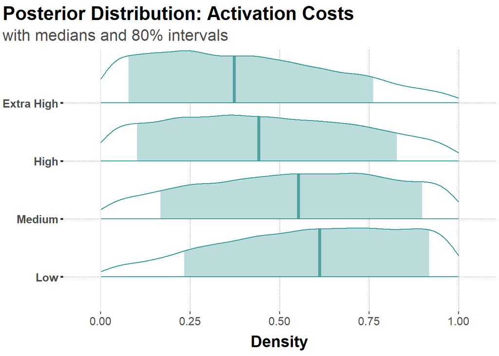

```r
Cost_Model_samples_matrix <- as.matrix(Cost_Model_samples)

costs_sample_plot_activation <- mcmc_areas(Cost_Model_samples_matrix,
      regex_pars = "costs\\[[1],[1-4]\\]", prob = 0.8) +
      scale_y_discrete(
      labels = c("costs[1,1]" = "Low",
             "costs[1,2]" = "Medium",
             "costs[1,3]" = "High",
             "costs[1,4]" = "Extra High")) +
       labs(x="Density",
   title = "Posterior Distribution: Activation Costs",
   subtitle = "with medians and 80% intervals") +
  theme(plot.title.position = "plot",
        plot.caption.position =  "plot")
color_scheme_set("purple")

costs_sample_plot_discovery <- mcmc_areas(Cost_Model_samples_matrix,
      regex_pars = "costs\\[[2],[1-4]\\]", prob = 0.8) +
      scale_y_discrete(
      labels = c(
             "costs[2,1]" = "Low",
             "costs[2,2]" = "Medium",
             "costs[2,3]" = "High",
             "costs[2,4]" = "Extra High")) +
       labs(x="Density",
   title = "Posterior Distributions: Discovery Costs",
   subtitle = "with medians and 80% intervals") +
  theme(plot.title.position = "plot",
        plot.caption.position =  "plot")
costs_sample_plot_activation
```

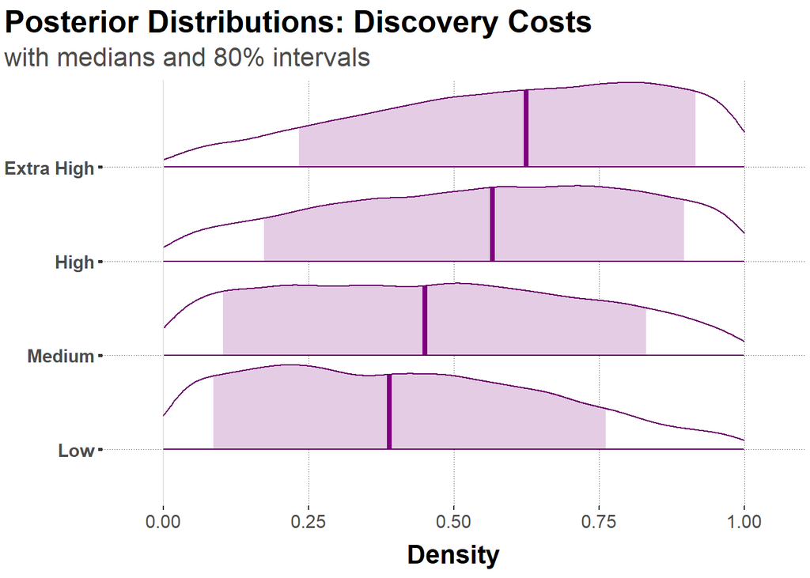

```r
dev.copy(png,filename="activation_costs.png")
dev.off ()

costs_sample_plot_discovery
```

```r
dev.copy(png,filename="discovery_costs.png")
dev.off ()
```

#### 2.4 Discovery Difficulty Model

Stan Model:

```stan
// Discovery Difficulty Model
// The model performs dual Bayesian inference over two distinct data sets: the main experiment data and norming study
// data from Bridgers et al. (2020) and estimates four separate levels for exploration certainty parameter

data {
  int<lower=1> n_conditions;
  int<lower=0> k[n_conditions];
  int<lower=1> n[n_conditions];
  int<lower=1> n_norm;
  int<lower=0> k_norm;

  // REWARDS indices
  int rewards_vec_red[n_conditions];
  int rewards_vec_yellow[n_conditions];

  // COSTS indices
  int cost_vec_red[n_conditions];
  int cost_vec_yellow[n_conditions];

  // COSTS
  real<lower=0, upper=1> costs[2,4];

}
parameters {

  // Exploration Parameter PE (one per toy difficulty level)
  real<lower=0, upper=1> explo_para[4];
}

model {
  real utility_toy_red;
  real utility_toy_yellow;
  real prob_choice_red;
  real prob_lights;

  // HYPERPARAMETER
  real alpha = 5;

  // REWARDS
  real rewards[2]  = {0.35, 0.65};

  // PRIOR
  for (i in 1:4) {
      explo_para[i] ~ beta(1,1);
  }

 // MAIN LOOP: going through all 6 conditions of the experiment

  for (i in 1:n_conditions) {

    // UTILITIES
    // computing utility values for red toy and yellow toy respectively, according to condition, with four separate exploration
    // certainty parameter settings depending on toy difficulty level
    utility_toy_red = rewards[rewards_vec_red[i]] - costs[1][cost_vec_red[i]] + explo_para[cost_vec_yellow[i]] * rewards[rewards_vec_yellow[i]] - costs[2][cost_vec_yellow[i]];
    utility_toy_yellow = rewards[rewards_vec_yellow[i]] - costs[1][cost_vec_yellow[i]] + explo_para[cost_vec_red[i]] * rewards[rewards_vec_red[i]] - costs[2][cost_vec_red[i]];

     // PROBABILITY FOR RED TOY
    // computing the probability for a child to choose the red toy using softmax choice rule
    prob_choice_red = exp(alpha * utility_toy_red) / (exp(alpha * utility_toy_red) + exp(alpha * utility_toy_yellow));

    // POSTERIOR
    // Observed amount of decisions for red toy
    k[i] ~ binomial(n[i], prob_choice_red);
  }

  // NORMING STUDY

  //PROBABILITY FOR LIGHT TOY
  // computing the probability for a child to choose the light toy using softmax choice rule
  prob_lights = exp(alpha * rewards[2]) / (exp(alpha * rewards[2]) + exp(alpha*rewards[1]));

  // NORMING STUDY POSTERIOR
  // Observed amount of decisions for light toy
  k_norm ~ binomial(n_norm, prob_lights);
}
```

```r
# running the Stan model

Discovery_Difficulty_Model <- stan(file='Models/Discovery_Difficulty_Model.stan',
                data=data_and_norm,
                iter=10000,
                chains=4,
                thin=1,
)
```

The following code chunk displays the data for Table 8:

```r
Discovery_Difficulty_Model
```

```
## Inference for Stan model: Discovery_Difficulty_Model.
## 4 chains, each with iter=10000; warmup=5000; thin=1;
## post-warmup draws per chain=5000, total post-warmup draws=20000.
##
##                  mean se_mean   sd    2.5%     25%     50%     75%   97.5%
## explo_para[1]    0.41    0.00 0.10    0.22    0.34    0.41    0.48    0.62
## explo_para[2]    0.26    0.00 0.20    0.01    0.11    0.22    0.38    0.74
## explo_para[3]    0.39    0.00 0.16    0.08    0.27    0.39    0.50    0.71
## explo_para[4]    0.85    0.00 0.14    0.48    0.79    0.89    0.95    1.00
## lp__          -137.76    0.02 1.71 -142.05 -138.57 -137.37 -136.50 -135.64
##               n_eff Rhat
## explo_para[1]  8185    1
## explo_para[2] 10793    1
## explo_para[3]  8747    1
## explo_para[4] 16459    1
## lp__           5994    1
##
## Samples were drawn using NUTS(diag_e) at Sat Feb 19 21:39:13 2022.
## For each parameter, n_eff is a crude measure of effective sample size,
## and Rhat is the potential scale reduction factor on split chains (at
## convergence, Rhat=1).
```

```r
Discovery_Difficulty_Model_tibble <- summary(Discovery_Difficulty_Model)$summary
print(xtable(Discovery_Difficulty_Model_tibble, type = "latex"), file = "discovery_difficulty_model_output.tex")
```

Hypothesis Tests for the Discovery Difficulty Model

The following code chunk displays the data for Table 9 from the thesis:

```r
Discovery_Difficulty_Model_hypothesis1 <- hypothesis(Discovery_Difficulty_Model, "explo_para[1] > explo_para[2]")
Discovery_Difficulty_Model_hypothesis2 <- hypothesis(Discovery_Difficulty_Model, "explo_para[3] > explo_para[2]")
Discovery_Difficulty_Model_hypothesis3 <- hypothesis(Discovery_Difficulty_Model, "explo_para[4] > explo_para[3]")

Discovery_Difficulty_Model_all_hypotheses <- bind_rows(Discovery_Difficulty_Model_hypothesis1$hypothesis,         Discovery_Difficulty_Model_hypothesis2$hypothesis,Discovery_Difficulty_Model_hypothesis3$hypothesis)

Discovery_Difficulty_Model_all_hypotheses
```

```
##                            Hypothesis  Estimate Est.Error   CI.Lower  CI.Upper
## 1 (explo_para[1])-(explo_para[2]) > 0 0.1442275 0.1695626 -0.1677766 0.3849406
## 2 (explo_para[3])-(explo_para[2]) > 0 0.1229683 0.2018627 -0.2249364 0.4368272
## 3 (explo_para[4])-(explo_para[3]) > 0 0.4621287 0.2007102  0.1148238 0.7747614
##   Evid.Ratio Post.Prob Star
## 1   4.189414   0.80730
## 2   2.845414   0.73995
## 3  51.083333   0.98080    *
```

```r
print(xtable(Discovery_Difficulty_Model_all_hypotheses, type = "latex"), file = "Discovery_Difficulty_Model_Hypothesis_Tests.tex")
```

The following code chunk creates Figure 12 from the thesis:

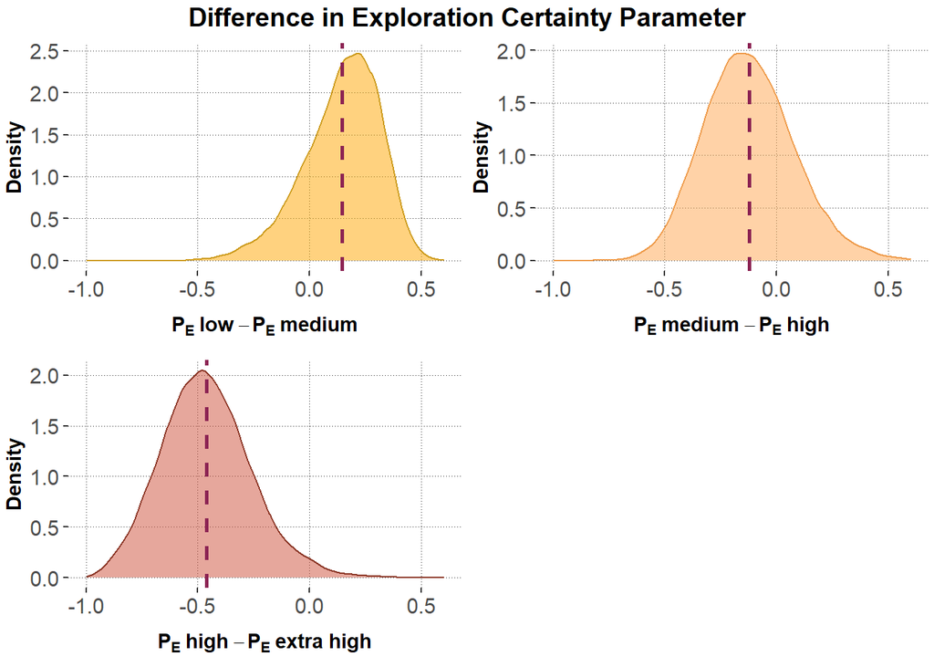

```r
Discovery_Difficulty_Model_samples <- tidybayes::tidy_draws(Discovery_Difficulty_Model)


Discovery_Difficulty_Model_samples_plus_differences <- Discovery_Difficulty_Model_samples %>%
                  mutate(`difference_level1_level2` = `explo_para[1]` - `explo_para[2]`,
                         mean_l1l2 = mean(difference_level1_level2),
                         difference_level2_level3 = `explo_para[2]` - `explo_para[3]`,
                         mean_l2l3 = mean(difference_level2_level3),
                         difference_level3_level4 = `explo_para[3]` - `explo_para[4]`,
                         mean_l3l4 = mean(difference_level3_level4))


mean_l1l2 <- Discovery_Difficulty_Model_samples_plus_differences$mean_l1l2

Discovery_Difficulty_Model_Differences_l1l2 <- ggplot(Discovery_Difficulty_Model_samples_plus_differences, aes(x=`difference_level1_level2`)) + geom_density(color="goldenrod3",fill="orange", alpha=0.5) + geom_vline(xintercept=mean_l1l2, color="violetred4", size=1,linetype="dashed") + labs(x=bquote(bold(P[E] ~ "low" ~ - P[E] ~ "medium")), y="Density") +
  theme(axis.title = element_text(size = 11)) + xlim(-1, 0.6)

mean_l2l3 <- Discovery_Difficulty_Model_samples_plus_differences$mean_l2l3

Discovery_Difficulty_Model_Differences_l2l3 <- ggplot(Discovery_Difficulty_Model_samples_plus_differences, aes(x=`difference_level2_level3`)) + geom_density(color="tan2",fill="tan1", alpha=0.5) + geom_vline(xintercept=mean_l2l3, color="violetred4", size=1,linetype="dashed") + labs(x=bquote(bold(P[E] ~ "medium" ~ - P[E] ~ "high")), y="Density") + theme(axis.title = element_text(size = 11)) + xlim(-1, 0.6)

mean_l3l4 <- Discovery_Difficulty_Model_samples_plus_differences$mean_l3l4

Discovery_Difficulty_Model_Differences_l3l4 <- ggplot(Discovery_Difficulty_Model_samples_plus_differences, aes(x=`difference_level3_level4`)) + geom_density(color="tomato4",fill="tomato3", alpha=0.5) + geom_vline(xintercept=mean_l3l4, color="violetred4", size=1,linetype="dashed") + labs(x=bquote(bold(P[E] ~ "high" ~ - P[E] ~ "extra high")), y="Density") + theme(axis.title = element_text(size = 11)) + xlim(-1, 0.6)

Discovery_Difficulty_Model_Posteriors <- ggpubr::ggarrange(Discovery_Difficulty_Model_Differences_l1l2, Discovery_Difficulty_Model_Differences_l2l3, Discovery_Difficulty_Model_Differences_l3l4) +
  labs(x=bquote(bold(P[E] ~ "high" ~ - P[E] ~ "extra high")), y="Density",
   title = "Difference in Exploration Certainty Parameter",
   subtitle = bquote("Posterior Densities (ordered)")) +
  theme(plot.title.position = "plot",
        plot.caption.position =  "plot")
Discovery_Difficulty_Model_Posteriors <- ggpubr::annotate_figure(
  Discovery_Difficulty_Model_Posteriors,
  top = text_grob("Difference in Exploration Certainty Parameter",
  size= 14,
  face="bold")
)

Discovery_Difficulty_Model_Posteriors
```

```r
dev.copy(png,filename="PE_differences.png")
dev.off ()
```